# Forest Type Prediction

Juan Mari Sebastian Carino

## Introduction

There are different forest types around the world and their differences usually involve with ecological factors, geographical locations, habitants, and weather. It is quite interesting how unique each forest type is. In this competition, we are given data relating to the forest type and the objective is to predict the forest type as accurately as possible. By diving with my knowledge in machine learning and performing two model testing, I have decided to use random forest since it generated a higher accuracy rate than the multinomial logistic regression. In my submission at Kaggle, I got a higher score using random forest than the multinomial logistic regression.

## Objective

The objective of this challenge is to predict the forest type based on various categorial and quantitative variables.

## Background

Since the objective is to create a model that will predict the cover type, it is best to describe the qualitative variable, forest cover and wilderness area.

### Cover Type

#### Spruce/Fir

Their spatial patterns are dependent on the temperature. Because of the thicker trunks, they are able to survive fires.

#### Lodgepole Pine

It is commonly located near the ocean shore and in dry montane forests to the subalpine. It is an evergreen pine.

#### Ponderosa Pine

Pinus ponderosa is a large coniferous pine (evergreen) tree. The bark helps to distinguish it from other species. Like most western pines, the ponderosa generally is associated with mountainous topography. *From Wikipedia*

#### Cottonwood/Willow

Poplars of the cottonwood section are often wetlands or riparian trees. The aspens are among the most important boreal broadleaf trees.

#### Aspen

Aspen trees are all native to cold regions with cool summers, in the north of the Northern Hemisphere, extending south at high-altitude areas such as mountains or high plains. Aspens typically grow in environments that are otherwise dominated by coniferous tree species, and which are often lacking other large deciduous tree species.

#### Douglas-fir

It is a coniferous type whose leaves are evergreen (i.e. always green in colors). It prefers neutral or acidic soils. This type is used widely for timber due to its strength, hardness, and durability.

#### Krummholz

It is a type of stunted, deformed vegetation encountered in the subarctic and subalpine tree line landscapes, shaped by continual exposure to fierce, freezing winds. Under these conditions, trees can only survive where they are sheltered by rock formations or snow cover. As the lower portion of these trees continues to grow, the coverage becomes extremely dense near the ground.

### Wilderness Type

Next, we will discuss the four wilderness type.

#### Rawah Wilderness

- protects a scenic high country of U-shaped glacier-carved valleys and peaks reaching 12, 951 feet.
- To the south and west of the area lies an almost roadless Colorado State Forest, an unofficial extension of the Wilderness.
- Melting snow fills 26 lakes within the area.
- On the upper forested slopes of the mountains, especially in the southern section, clusters of old-growth spruce and fir abound.
- has a total of 74,408 acres.
- located on the Canyon Lakes Ranger District of the Roosevelt National Forest in Colorado near the Wyoming border and also in the Routt National Forest to its south.
- There are 85 miles (137 km) of trails in the area and elevation ranges from 8,400 feet (2,600 m) to 13,0000 feet (4,000 m).
- The temperature in the Rawah Wilderness ranges from a low of 5 degrees Fahrenheit during the winder and a high of 77 degrees Fahrenheit during the summer.

#### Neota Wilderness

- located on the Canyon Lakes Ranger District of the Roosevelt National Forest in Colorado.
- This wilderness area encompasses 9,924 acres (40 km2) and is bordered on the south by Rocky Mountain National Park.
  - Elevation ranges frm 10,000 ft (3,000 m) to 11,9896 ft (3,626 m) in the Rocky Mountains. There are only .5 miles (2.4 km) of trail in this area.
  - bordered by the Rawah Wilderness to the northwest, the COmanche Peak Wilderness to the east, and the Rocky Mountain National Park Wilderness to the south.

#### Comanche Peak Wilderness

- located in the Roosevelt National Forest on the Canyon Lakes Ranger District in Colorado along the northern boundary of Rocky Mountain National Park.
- comprises of 66,791-acre (27, 029 ha).
- There are 121 miles (195 km) of hiking trails inside the wilderness.
- There are also 7 named peaks, 6 named lakes (inclduing COmanche Reservoir) and 16 named rivers and creeks within the wilderness boundaries.
- From the trails, the Wilderness appears to be nothing but trees until the forst gives way to abundant alpine tundra along the souther boundary near Comanche Peak.
- Beyond Comanche to the South lies Rocky Mountain National Park.
- The Cache la Poudre River tumbles over cascades or runs quietly in pools for over 10 miles to the north and west.

#### Cache La Poudre Wilderness

- located on the Canyon Lakes Ranger District on the Roosevelt National Forest in Colorado.
- This wilderness covers 9,258 acres (37.47 km2) and is characterized by steep, rugged terrain along the Cache la Poudre River.
- Elevations in this area varies from 6,200 feet(1,900 m) to 8,600 feet (2,600 m).

## Data Loading and Initial Analysis

First, the researcher will load the libraries to be used in the analysis, the data itself, and do the preliminary analysis. This analysis will involve looking at the data type and number of null values.

```r
## Loading the libraries
library(ggplot2)
library(tidyverse)
library(dplyr)
library(caret)
library(randomForest)
library(reshape2)


## Loading the datasets

    train <- read.csv("train.csv", header = TRUE)

    ## Due to the limited computing power of my computer, I have divided the test data set into six. These data sets are already processed.
    test1 <- read.csv("test1.csv", header = TRUE)
    test2 <- read.csv("test2.csv", header = TRUE)
    test3 <- read.csv("test3.csv", header = TRUE)
    test4 <- read.csv("test4.csv", header = TRUE)
    test5 <- read.csv("test5.csv", header = TRUE)
    test6 <- read.csv("test6.csv", header = TRUE)

    ## Combining all of the datasets into one
    test <- rbind(test1, test2, test3, test4, test5, test6)

    ## Renaming the Area Type and Soil Type columns of the test dataset
    names(test)[12:13] <- c("Area_Type", "Soil_Type")

## Number of observations
data.frame(data = c("train", "test"), columns = c(ncol(train), ncol(test)), rows = c(nrow(train), nrow(test)))
```

```
##    data columns   rows
## 1 train      56  15120
## 2  test      13 565892
```

```r
## Number of null values in train set
colSums(is.na(train))
```

```
##                                 Id                          Elevation
##                                  0                                  0
##                             Aspect                              Slope
##                                  0                                  0
##   Horizontal_Distance_To_Hydrology     Vertical_Distance_To_Hydrology
##                                  0                                  0
##    Horizontal_Distance_To_Roadways                      Hillshade_9am
##                                  0                                  0
##                     Hillshade_Noon                      Hillshade_3pm
##                                  0                                  0
## Horizontal_Distance_To_Fire_Points                   Wilderness_Area1
##                                  0                                  0
##                   Wilderness_Area2                   Wilderness_Area3
##                                  0                                  0
##                   Wilderness_Area4                         Soil_Type1
##                                  0                                  0
##                         Soil_Type2                         Soil_Type3
##                                  0                                  0
##                         Soil_Type4                         Soil_Type5
##                                  0                                  0
##                         Soil_Type6                         Soil_Type7
##                                  0                                  0
##                         Soil_Type8                         Soil_Type9
##                                  0                                  0
##                        Soil_Type10                        Soil_Type11
##                                  0                                  0
##                        Soil_Type12                        Soil_Type13
##                                  0                                  0
##                        Soil_Type14                        Soil_Type15
##                                  0                                  0
##                        Soil_Type16                        Soil_Type17
##                                  0                                  0
##                        Soil_Type18                        Soil_Type19
##                                  0                                  0
##                        Soil_Type20                        Soil_Type21
##                                  0                                  0
##                        Soil_Type22                        Soil_Type23
##                                  0                                  0
##                        Soil_Type24                        Soil_Type25
##                                  0                                  0
##                        Soil_Type26                        Soil_Type27
##                                  0                                  0
##                        Soil_Type28                        Soil_Type29
##                                  0                                  0
##                        Soil_Type30                        Soil_Type31
##                                  0                                  0
##                        Soil_Type32                        Soil_Type33
##                                  0                                  0
##                        Soil_Type34                        Soil_Type35
##                                  0                                  0
##                        Soil_Type36                        Soil_Type37
##                                  0                                  0
##                        Soil_Type38                        Soil_Type39
##                                  0                                  0
##                        Soil_Type40                         Cover_Type
##                                  0                                  0
```

```r
## Number of null values in test set
colSums(is.na(test))
```

```
##                              ï..Id                          Elevation
##                                  0                                  0
##                             Aspect                              Slope
##                                  0                                  0
##   Horizontal_Distance_To_Hydrology     Vertical_Distance_To_Hydrology
##                                  0                                  0
##    Horizontal_Distance_To_Roadways                      Hillshade_9am
##                                  0                                  0
##                     Hillshade_Noon                      Hillshade_3pm
##                                  0                                  0
## Horizontal_Distance_To_Fire_Points                          Area_Type
##                                  0                                  0
##                          Soil_Type
##                                  0
```

It can be seen that there are no null values in our dataset.

## Data Cleaning

Second, the researcher will clean the data. The following will be performed during the cleaning:

1. Conversion of categorical variables into factor class.
2. Melting the Wilderness Area variables.
3. Melting the Soil Type variables.
4. Removing observations where the wilderness area and soil type are zero.
5. Converting the Elevation, Aspect, Slope, Horizontal Distance to Fire Points and Hydrology, Vertical Distance to Roadways and Hydrology, and Hillshade into numeric class.

In addition to that, I have replaced grouped the soil type with similar features.

```r
## Replacing the numeric values into text values

    train$Wilderness_Area1 <- ifelse(train$Wilderness_Area1 == 1, "Rawah", train$Wilderness_Area1)
    train$Wilderness_Area2 <- ifelse(train$Wilderness_Area2 == 1, "Neota", train$Wilderness_Area2)
    train$Wilderness_Area3 <- ifelse(train$Wilderness_Area3 == 1, "Comanche Peak", train$Wilderness_Area3)
    train$Wilderness_Area4 <- ifelse(train$Wilderness_Area4 == 1, "Cache la Poudre", train$Wilderness_Area4)

    train$Soil_Type1 <- ifelse(train$Soil_Type1 == 1, "Cathedral Family", train$Soil_Type1)
    train$Soil_Type2 <- ifelse(train$Soil_Type2 == 1, "Vanet", train$Soil_Type2)
    train$Soil_Type3 <- ifelse(train$Soil_Type3 == 1, "Haploborolis", train$Soil_Type3)
    train$Soil_Type4 <- ifelse(train$Soil_Type4 == 1, "Ratake family", train$Soil_Type4)
    train$Soil_Type5 <- ifelse(train$Soil_Type5 == 1, "Vanet", train$Soil_Type5)
    train$Soil_Type6 <- ifelse(train$Soil_Type6 == 1, "Vanet", train$Soil_Type6)
    train$Soil_Type7 <- ifelse(train$Soil_Type7 == 1, "Gothic", train$Soil_Type7)
    train$Soil_Type8 <- ifelse(train$Soil_Type8 == 1, "Supervisor", train$Soil_Type8)
    train$Soil_Type9 <- ifelse(train$Soil_Type9 == 1, "Troutville", train$Soil_Type9)
    train$Soil_Type10 <- ifelse(train$Soil_Type10 == 1, "Bullwark", train$Soil_Type10)
    train$Soil_Type11 <- ifelse(train$Soil_Type11 == 1, "Bullwark", train$Soil_Type11)
    train$Soil_Type12 <- ifelse(train$Soil_Type12 == 1, "Legault", train$Soil_Type12)
    train$Soil_Type13 <- ifelse(train$Soil_Type13 == 1, "Catamount", train$Soil_Type13)
    train$Soil_Type14 <- ifelse(train$Soil_Type14 == 1, "Pachic", train$Soil_Type14)
    train$Soil_Type15 <- ifelse(train$Soil_Type15 == 1, "unspecified", train$Soil_Type15)
    train$Soil_Type16 <- ifelse(train$Soil_Type16 == 1, "Cryaquolis", train$Soil_Type16)
    train$Soil_Type17 <- ifelse(train$Soil_Type17 == 1, "Gateview", train$Soil_Type17)
    train$Soil_Type18 <- ifelse(train$Soil_Type18 == 1, "Rogert", train$Soil_Type18)
    train$Soil_Type19 <- ifelse(train$Soil_Type19 == 1, "Typic", train$Soil_Type19)
    train$Soil_Type20 <- ifelse(train$Soil_Type20 == 1, "Typic", train$Soil_Type20)
    train$Soil_Type21 <- ifelse(train$Soil_Type21 == 1, "Typic", train$Soil_Type21)
    train$Soil_Type22 <- ifelse(train$Soil_Type22 == 1, "Leighcan", train$Soil_Type22)
    train$Soil_Type23 <- ifelse(train$Soil_Type23 == 1, "Leighcan", train$Soil_Type23)
    train$Soil_Type24 <- ifelse(train$Soil_Type24 == 1, "Leighcan", train$Soil_Type24)
    train$Soil_Type25 <- ifelse(train$Soil_Type25 == 1, "Leighcan", train$Soil_Type25)
    train$Soil_Type26 <- ifelse(train$Soil_Type26 == 1, "Granile", train$Soil_Type26)
    train$Soil_Type27 <- ifelse(train$Soil_Type27 == 1, "Leighcan", train$Soil_Type27)
    train$Soil_Type28 <- ifelse(train$Soil_Type28 == 1, "Leighcan", train$Soil_Type28)
    train$Soil_Type29 <- ifelse(train$Soil_Type29 == 1, "Como", train$Soil_Type29)
    train$Soil_Type30 <- ifelse(train$Soil_Type30 == 1, "Como", train$Soil_Type30)
    train$Soil_Type31 <- ifelse(train$Soil_Type31 == 1, "Leighcan", train$Soil_Type31)
    train$Soil_Type32 <- ifelse(train$Soil_Type32 == 1, "Catamount", train$Soil_Type32)
    train$Soil_Type33 <- ifelse(train$Soil_Type33 == 1, "Leighcan", train$Soil_Type33)
    train$Soil_Type34 <- ifelse(train$Soil_Type34 == 1, "Cryorthents", train$Soil_Type34)
    train$Soil_Type35 <- ifelse(train$Soil_Type35 == 1, "Cryumbrepts", train$Soil_Type35)
    train$Soil_Type36 <- ifelse(train$Soil_Type36 == 1, "Bross", train$Soil_Type36)
    train$Soil_Type37 <- ifelse(train$Soil_Type37 == 1, "Cryumbrepts", train$Soil_Type37)
    train$Soil_Type38 <- ifelse(train$Soil_Type38 == 1, "Leighcan", train$Soil_Type38)
    train$Soil_Type39 <- ifelse(train$Soil_Type39 == 1, "Moran", train$Soil_Type39)
    train$Soil_Type40 <- ifelse(train$Soil_Type40 == 1, "Moran", train$Soil_Type40)

## Melting the dataset

    train <- train %>%
                gather(key = "Wilderness Area", value = "Area_Type", 12:15) %>%
                gather(key = "Soil", value = "Soil_Type", Soil_Type1:Soil_Type40)

## Converting the Cover Type, Area Type, and Soil Type into factors
    train$Cover_Type <- as.factor(train$Cover_Type)
    train$Area_Type <- as.factor(train$Area_Type)
    train$Soil_Type <- as.factor(train$Soil_Type)

## Removing observations where the wilderness area and soil type are zero.

    train <- train[!(train$Area_Type %in% c(0)), ]
    train <- train[!(train$Soil_Type %in% c(0)), ]
    train <- select(train, -`Wilderness Area`, -Soil)


## Converting other variables into numeric type
    train$Elevation <- as.numeric(train$Elevation)
    train$Aspect <- as.numeric(train$Aspect)
    train$Slope <- as.numeric(train$Slope)
    train$Horizontal_Distance_To_Fire_Points <- as.numeric(train$Horizontal_Distance_To_Fire_Points)
    train$Vertical_Distance_To_Hydrology <- as.numeric(train$Vertical_Distance_To_Hydrology)
    train$Horizontal_Distance_To_Hydrology <- as.numeric(train$Horizontal_Distance_To_Hydrology)
    train$Horizontal_Distance_To_Roadways <- as.numeric(train$Horizontal_Distance_To_Roadways)
    train$Hillshade_3pm <- as.numeric(train$Hillshade_3pm)
    train$Hillshade_9am <- as.numeric(train$Hillshade_9am)
    train$Hillshade_Noon <- as.numeric(train$Hillshade_Noon)
```

## Data Exploration

Next, we are going to use ggplot in generating graphs.

Presented below is the descriptive statistics.

```r
## Descriptive Statistics
summary(train)
```

```
##        Id          Elevation        Aspect          Slope
##  Min.   :    1   Min.   :1863   Min.   :  0.0   Min.   : 0.0
##  1st Qu.: 3781   1st Qu.:2376   1st Qu.: 65.0   1st Qu.:10.0
##  Median : 7560   Median :2752   Median :126.0   Median :15.0
##  Mean   : 7560   Mean   :2749   Mean   :156.7   Mean   :16.5
##  3rd Qu.:11340   3rd Qu.:3104   3rd Qu.:261.0   3rd Qu.:22.0
##  Max.   :15120   Max.   :3849   Max.   :360.0   Max.   :52.0
##
##  Horizontal_Distance_To_Hydrology Vertical_Distance_To_Hydrology
##  Min.   :   0.0                   Min.   :-146.00
##  1st Qu.:  67.0                   1st Qu.:   5.00
##  Median : 180.0                   Median :  32.00
##  Mean   : 227.2                   Mean   :  51.08
##  3rd Qu.: 330.0                   3rd Qu.:  79.00
##  Max.   :1343.0                   Max.   : 554.00
##
##  Horizontal_Distance_To_Roadways Hillshade_9am   Hillshade_Noon
##  Min.   :   0                    Min.   :  0.0   Min.   : 99
##  1st Qu.: 764                    1st Qu.:196.0   1st Qu.:207
##  Median :1316                    Median :220.0   Median :223
##  Mean   :1714                    Mean   :212.7   Mean   :219
##  3rd Qu.:2270                    3rd Qu.:235.0   3rd Qu.:235
##  Max.   :6890                    Max.   :254.0   Max.   :254
##
##  Hillshade_3pm   Horizontal_Distance_To_Fire_Points Cover_Type
##  Min.   :  0.0   Min.   :   0                       1:2160
##  1st Qu.:106.0   1st Qu.: 730                       2:2160
##  Median :138.0   Median :1256                       3:2160
##  Mean   :135.1   Mean   :1511                       4:2160
##  3rd Qu.:167.0   3rd Qu.:1988                       5:2160
##  Max.   :248.0   Max.   :6993                       6:2160
##                                                     7:2160
##            Area_Type        Soil_Type
##  0              :   0   Leighcan :3060
##  Cache la Poudre:4675   Bullwark :2548
##  Comanche Peak  :6349   Como     :2016
##  Neota          : 499   Vanet    :1438
##  Rawah          :3597   Catamount:1166
##                         Moran    :1116
##                         (Other)  :3776
```

Remember the following integer represents each cover type: 1 - Spruce/Fir 2 - Lodgepole Pine 3 - Ponderosa Pine 4 - Cottonwood/Willow 5 - Aspen 6 - Douglas-fir 7 - Krummholz

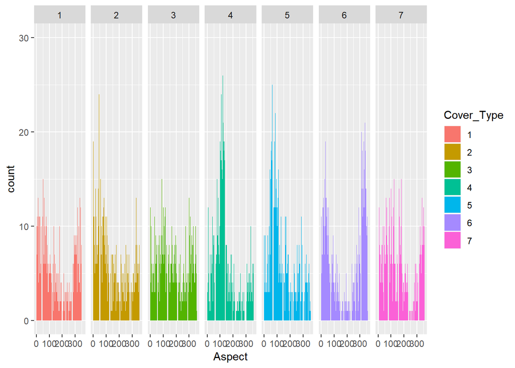

```r
## Aspect
g <- ggplot(data = train, aes(x = Aspect, fill = Cover_Type))
g + geom_bar() + facet_grid(.~Cover_Type)
```

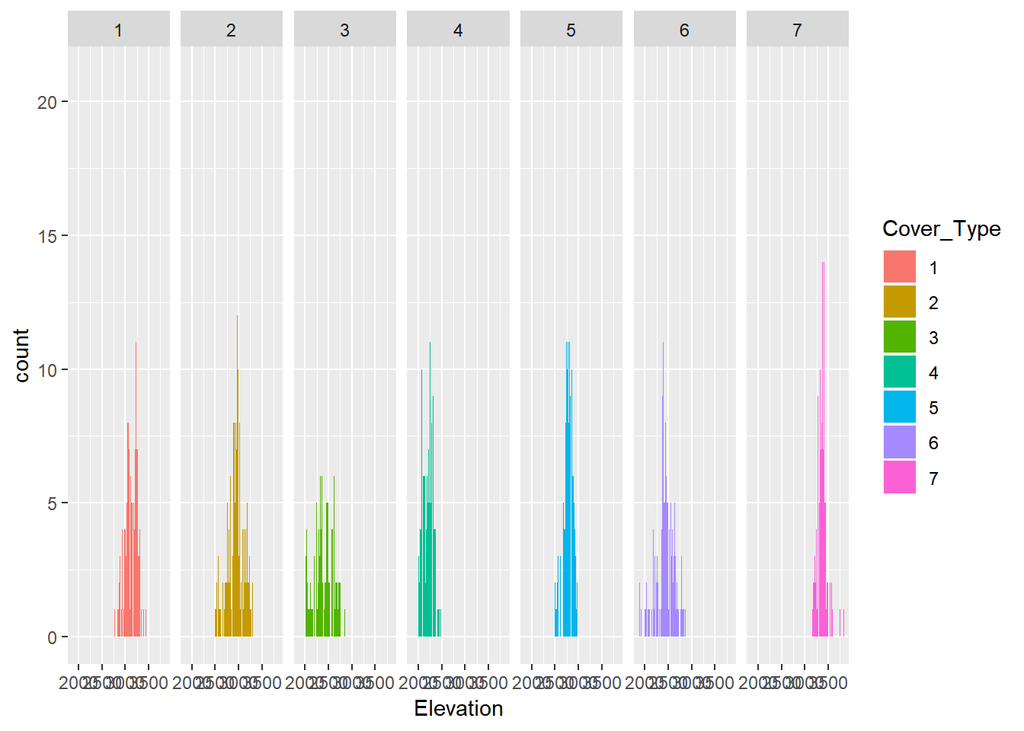

```r
## Elevation
h <- ggplot(data = train, aes(x = Elevation, fill = Cover_Type))
h + geom_bar() + facet_grid(.~Cover_Type)
```

## Machine Learning Modelling

In our dataset, we are going to use multinomial logistic regression. Multinomial logistic regression allows for more than two categories of the dependent variable. In this dataset, we have used the nnet library where neural networks are going to be used to work hand in hand in performing multinomial logistic regression.

Diagnostic tests to be performed will only be Variable Importance

```r
## Dividing the train set into two: training and validation datasets
    inTrain <- createDataPartition(y = train$Cover_Type, p = 0.70, list = FALSE)
    training <- train[inTrain, ]
    validation <- train[-inTrain, ]

## Creating a predictive model
    library(nnet)
    model <- multinom(Cover_Type ~. -Id, data = training, maxit=500, trace = TRUE)
## Measuring the variance importance
    ImpVar <- varImp(model)
    ImpVar$Variables <- row.names(ImpVar)
    ImpVar <- ImpVar[order(-ImpVar$Overall), ]
    print(head(ImpVar))
```

[output not shown]

It looks like most important variables are area type and soil type. Next, we are going to predict the cover type.

```r
## Summary
summary(model)
```

```
## Call:
## multinom(formula = Cover_Type ~ . - Id, data = training, maxit = 500,
##     trace = TRUE)
##
## Coefficients:
##   (Intercept)    Elevation        Aspect       Slope
## 2    17.96795 -0.009267891 -0.0009280679  0.04934965
## 3    54.94883 -0.034534363  0.0047149424  0.10371677
## 4    58.11421 -0.040739166  0.0033257121  0.05002970
## 5    21.99264 -0.015917967  0.0033975444  0.03729762
## 6    41.69034 -0.034394115  0.0043080497  0.18710687
## 7   -50.58038  0.021716394  0.0012262861 -0.04535657
##   Horizontal_Distance_To_Hydrology Vertical_Distance_To_Hydrology
## 2                     0.0018488629                    0.002519815
## 3                     0.0023276145                    0.017542791
```

[output cut: 177 more lines]

```r
prediction <- predict(model, newdata=validation)
postResample(prediction, validation$Cover_Type)
```

```
##  Accuracy     Kappa
## 0.6940035 0.6430041
```

Randomforest is a type of algorithm that ensemble learning method for classification, regression and other tasks, that operate by constructing a multitude of decision trees at training time and outputting the class that is the mode of the classes (classification) or mean prediction (regression) of the individual trees.

It can handle categorical and numerical variables.

```r
## Creating a predictive model using randomforest
names(training)[13:14] <- c("Area_Type", "Soil_Type")
model2 <- randomForest(Cover_Type ~. -Id, data = training)

## Overview of the model
model2
```

```
##
## Call:
##  randomForest(formula = Cover_Type ~ . - Id, data = training)
##                Type of random forest: classification
##                      Number of trees: 500
## No. of variables tried at each split: 3
##
##         OOB estimate of  error rate: 14.3%
## Confusion matrix:
##      1    2    3    4    5    6    7 class.error
## 1 1160  216    2    0   35    4   95  0.23280423
## 2  269 1014   38    0  126   47   18  0.32936508
## 3    0    8 1235   72   14  183    0  0.18320106
## 4    0    0   29 1465    0   18    0  0.03108466
## 5    3   35   20    0 1436   18    0  0.05026455
## 6    1    9  148   37   13 1304    0  0.13756614
## 7   52    3    0    0    1    0 1456  0.03703704
```

```r
## Measuring the variance importance
    ImpVar <- varImp(model2)
    ImpVar$Variables <- row.names(ImpVar)
    ImpVar <- ImpVar[order(-ImpVar$Overall), ]
    print(head(ImpVar))
```

```
##                                      Overall
## Elevation                          2493.6424
## Soil_Type                          1269.2659
## Horizontal_Distance_To_Roadways     853.0528
## Horizontal_Distance_To_Fire_Points  697.9085
## Area_Type                           584.9208
## Horizontal_Distance_To_Hydrology    581.9755
##                                                             Variables
## Elevation                                                   Elevation
## Soil_Type                                                   Soil_Type
## Horizontal_Distance_To_Roadways       Horizontal_Distance_To_Roadways
## Horizontal_Distance_To_Fire_Points Horizontal_Distance_To_Fire_Points
## Area_Type                                                   Area_Type
## Horizontal_Distance_To_Hydrology     Horizontal_Distance_To_Hydrology
```

Next, we will test the accuracy of this model by applying it to the validation test.

```r
## Applying the model to the validation set
names(validation)[13:14] <- c("Area_Type", "Soil_Type")
prediction2 <- predict(model2, newdata = validation)

## Getting the accuracy
postResample(prediction2, validation$Cover_Type)
```

```
##  Accuracy     Kappa
## 0.8648589 0.8423354
```

## Model Application on the Test Dataset

Now, we are going to use the model itself to predict the test set and submit it to Kaggle.

```r
## Applying the random forest model to test set
## names(test)[c(1, 12:13)] <- c("Id","Area_Type", "Soil_Type")
## test_prediction <- predict(model2, newdata = test)

## Storing in a dataframe the result
## submission <- data.frame(Id = test$Id, Cover_Type = test_prediction)

## library(xlsx)
## write.csv(submission, file = "final_submission.xlsx")
```

## Conclusion

Initially, when I uploaded my submission using the multinomial logistic regression model, the score I got was just 34.202%. This means that the model fails to predict the test set and calls for improvement or revision of the model. Now, when I uploaded my submission using the random forest model, the score improved drastically to 67.715%.